# My first Quarto document

# Intro

**Macalester College** is in the *Twin Cities*. It has:

- four seasons
- bagpipes
- delightful students

Check it out for yourself:

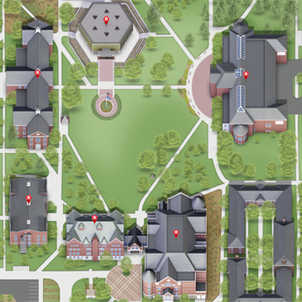

# Exercise 1: Deduce Quarto features

Check out the appearance and contents of this document. Thoughts?

In the toolbar at the top of this document, **Render** the .qmd file into a .html file. Where is this file stored? Thoughts about its appearance / contents? Can you edit it?

Toggling between the .qmd and .html files, explain the purpose of the following features in the .qmd file:

`*`

`**`

`#`

`-`

`\`

`![](url)`

# Exercise 2: Code

How does this appear in the .qmd? The .html? So…?!

seq(from = 100, to = 1000, by = 50)

# Exercise 3: Chunks

Quarto isn’t a mind reader – we must distinguish R code from text. We do so by putting code inside an **R chunk**:

```r
seq()
```

```
[1] 1
```

- Put the `seq()` code in the chunk.
- Press the green arrow in the top right of the chunk. What happens in the qmd?
- Render. What appears in the html: R code, output, or both?

# Exercise 4: Practice

- Use R code to create the following sequence: 10 10 10 10
- Store the sequence as `four_tens`.
- Use an R function (which we haven’t learned!) to add up the numbers in `four_tens`.

# Exercise 5: Fix this code

Code is a form of communication, and the code below doesn’t cut it.

Put the code in a chunk and fix it.

Rep(x = 1, times = 10) seq(from=100,to=1000,length=20) theNumberofStudentsinthisclass<-27